# Covid19 data analysis

Data Analysis on Covid19 dataset in India

We update statistics twice a day

From World Health Organization on 31 December 2019 alerted to several cases of pneumonia in Wuhan City, Hubei Province of China. The virus did not match any other known virus. This raised concern because when a virus is new, we do not know how it affects people.

2019 Novel Coronavirus (2019-nCoV) is a virus (more specifically, a coronavirus) identified as the cause of an outbreak of respiratory illness first detected in Wuhan, China. Early on, many of the patients in the outbreak in Wuhan, China reportedly had some link to a large seafood and animal market, suggesting animal-to-person spread. However, a growing number of patients reportedly have not had exposure to animal markets, indicating person-to-person spread is occurring. At this time, it’s unclear how easily or sustainably this virus is spreading between people.

Following analysis is for India using the data available in public domain. [Click here](https://www.covid19india.org) to get the interactive dashboard on Covid19 in India. There are four APIs giving all the data necessary for doing analysis.

- https://api.covid19india.org/data.json
- https://api.covid19india.org/state_district_wise.json
- https://api.covid19india.org/travel_history.json
- https://api.covid19india.org/raw_data.json

**API** is the acronym for *Application Programming Interface*. It is a tool that helps in the interaction between computer programs and web services.

**JSON** stands for *JavaScript Object Notation*. It is lightweight format for storing and transporting data and often used when data is sent from a server to a web page.

```python
%reset -f
import warnings
warnings.filterwarnings("ignore")# To ignore the warnings
```

```python
%%writefile corona.py
import pandas as pd # Library to read and write the data in structure format
import numpy as np # Library to deal with vector, array and matrices
import requests # Library to read APIs
import re # Library for regular expression
import json # Library to read and write JSON file
from bs4 import BeautifulSoup # Library for web scraping
####################################### APIs to be scrapped to getting real time Corna data ############################
moh_link = "https://www.mohfw.gov.in/"
url_state = "https://api.covid19india.org/state_district_wise.json"
data_data = "https://api.covid19india.org/data.json"
travel_history="https://api.covid19india.org/travel_history.json"
raw_data="https://api.covid19india.org/raw_data.json"


class COVID19India(object):
    def __init__(self):
        self.moh_url = moh_link  # Ministry of Health and Family welfare website
        self.url_state = url_state  # districtwise data
        self.data_url = data_data  # All India data ==> Statewise data, test data, timeseries data etc
        self.travel_history_url=travel_history # Travel history of Patient
        self.raw_data_url=raw_data
    def __request(self, url):
        content=requests.get(url).json()
        return content
    def moh_data(self):
        url = self.moh_url
        df = pd.read_html(url)[-1].iloc[:-1]
        del df['S. No.']
        cols = df.columns.values.tolist()
        return df
    def statewise(self):
        data=self.__request(self.data_url)
#         delta=pd.DataFrame(data.get('key_values'))
        statewise=pd.DataFrame(data.get('statewise'))
#         statewise=pd.concat([pd.DataFrame(data.get('statewise')),pd.DataFrame([i.get('delta') for i in data.get('statewise')])],axis=1)
#         del statewise["delta"]
        cases_time_series=pd.DataFrame(data.get('cases_time_series'))
        tested=pd.DataFrame(data.get('tested'))
        return(statewise,cases_time_series,tested)
    def state_district_data(self):
        state_data = self.__request(self.url_state)
        key1 = state_data.keys()
        Values = []
        for k in key1:
            key2 = state_data[k]['districtData'].keys()
            for k2 in key2:
                c = list(state_data[k]['districtData'][k2].values())
                v = [k, k2, c[0]]
                Values.append(v)
        state_data = pd.DataFrame(Values,columns=['State_UT', 'District', 'Confirmed'])
        return state_data
    def travel_history(self):
        history_data = self.__request(self.travel_history_url)
        travel=pd.DataFrame(history_data.get("travel_history"))
        return(travel)
    def raw_data_info(self):
        raw = self.__request(self.raw_data_url)
        data=pd.DataFrame(raw.get("raw_data"))
        return(data)
```

```
Overwriting corona.py
```

To delete the memory in notebook to utilize the corona library

```python
%reset -f
import warnings
warnings.filterwarnings("ignore")# To ignore the warnings
import matplotlib.pyplot as plt# Python library for plotting graphs
plot_size = plt.rcParams["figure.figsize"]
plot_size[0] = 12
plot_size[1] = 3
plt.rcParams["figure.figsize"]
%matplotlib notebook
```

```python
from corona import COVID19India
coviddata=COVID19India()
```

# [Ministry of Health and Family welfare](https://www.mohfw.gov.in/) data analysis

```python
# importing the libraries
from bs4 import BeautifulSoup
import requests
import pandas as pd
url="https://www.mohfw.gov.in/"
html_content = requests.get(url).text
# Parse the html content
soup = BeautifulSoup(html_content, "lxml")
name  = soup.find_all('div', { "class" :"status-update"})
value = soup.find_all('h2')
print([row.get_text() for row in value][0])
```

```
COVID-19 INDIA as on : 12 April 2020, 08:00 GMT+5:30
```

```python
mohwf=coviddata.moh_data()[:-1]
mohwf.iloc[:,1:4]=mohwf.iloc[:,1:4].astype(int)
mohwf
```

|  | Name of State / UT | Total Confirmed cases (Including 71 foreign Nationals) | Cured/Discharged/Migrated | Death |
| --- | --- | --- | --- | --- |
| 0 | Andhra Pradesh | 381 | 11 | 6 |
| 1 | Andaman and Nicobar Islands | 11 | 10 | 0 |
| 2 | Arunachal Pradesh | 1 | 0 | 0 |
| 3 | Assam | 29 | 0 | 1 |
| 4 | Bihar | 63 | 0 | 1 |
| 5 | Chandigarh | 19 | 7 | 0 |
| 6 | Chhattisgarh | 18 | 9 | 0 |
| 7 | Delhi | 1069 | 25 | 19 |
| 8 | Goa | 7 | 5 | 0 |
| 9 | Gujarat | 432 | 44 | 22 |
| 10 | Haryana | 177 | 29 | 3 |
| 11 | Himachal Pradesh | 32 | 6 | 1 |
| 12 | Jammu and Kashmir | 207 | 6 | 4 |
| 13 | Jharkhand | 17 | 0 | 1 |
| 14 | Karnataka | 214 | 37 | 6 |
| 15 | Kerala | 364 | 123 | 2 |
| 16 | Ladakh | 15 | 10 | 0 |
| 17 | Madhya Pradesh | 532 | 0 | 36 |
| 18 | Maharashtra | 1761 | 208 | 127 |
| 19 | Manipur | 2 | 1 | 0 |
| 20 | Mizoram | 1 | 0 | 0 |
| 21 | Odisha | 50 | 2 | 1 |
| 22 | Puducherry | 7 | 1 | 0 |
| 23 | Punjab | 151 | 5 | 11 |
| 24 | Rajasthan | 700 | 21 | 3 |
| 25 | Tamil Nadu | 969 | 44 | 10 |
| 26 | Telengana | 504 | 43 | 9 |
| 27 | Tripura | 2 | 0 | 0 |
| 28 | Uttarakhand | 35 | 5 | 0 |
| 29 | Uttar Pradesh | 452 | 45 | 5 |
| 30 | West Bengal | 134 | 19 | 5 |

```python
print("Ministry of Health and Family welfare report")
mohwf.sum()[1:]
```

```
Ministry of Health and Family welfare report
```

```
Total Confirmed cases (Including 71 foreign Nationals)    8356
Cured/Discharged/Migrated                                  716
Death                                                      273
dtype: object
```

```python
mohwf.iloc[:,1:4].astype(int).describe()
```

|  | Total Confirmed cases (Including 71 foreign Nationals) | Cured/Discharged/Migrated | Death |
| --- | --- | --- | --- |
| count | 31.000000 | 31.000000 | 31.000000 |
| mean | 269.548387 | 23.096774 | 8.806452 |
| std | 399.909976 | 42.364572 | 23.332980 |
| min | 1.000000 | 0.000000 | 0.000000 |
| 25% | 16.000000 | 1.000000 | 0.000000 |
| 50% | 63.000000 | 7.000000 | 1.000000 |
| 75% | 406.500000 | 27.000000 | 6.000000 |
| max | 1761.000000 | 208.000000 | 127.000000 |

```python
corr = mohwf.iloc[:,1:4].astype(int).corr(method ='spearman')
corr.style.background_gradient(cmap='coolwarm')
```

|  | Total Confirmed cases (Including 71 foreign Nationals) | Cured/Discharged/Migrated | Death |
| --- | --- | --- | --- |
| Total Confirmed cases (Including 71 foreign Nationals) | 1.000000 | 0.693406 | 0.900629 |
| Cured/Discharged/Migrated | 0.693406 | 1.000000 | 0.544357 |
| Death | 0.900629 | 0.544357 | 1.000000 |

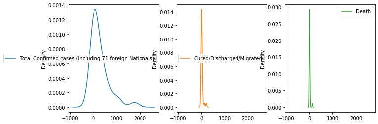

```python
import matplotlib.pyplot as plt
%matplotlib inline
plot_size = plt.rcParams["figure.figsize"]
plot_size[0] = 15
plot_size[1] = 4
plt.rcParams["figure.figsize"] = plot_size
mohwf.iloc[:,1:].plot(kind='density', subplots=True, layout=(1,4), sharex=True)
plt.show()
```

The peaks of a Density Plot help display where values are concentrated over the interval. This graphs infer India in still in still [stage 2](https://www.connectedtoindia.com/the-four-stages-of-covid-19-explained-7280.html) of the Covid19.

`Probability density is the probability per unit on the x-axis`

**Stage 1**: When cases are only imported from affected countries and therefore only those who have travelled abroad test positive. At this stage there is no spread of the disease locally.

**Stage 2**: When there is local transmission from infected persons. This will usually be relatives or acquaintances of those who travelled abroad who test positive after close contact with the infected person.

At this stage, fewer people are affected, the source of the virus is known and is therefore easier to perform contact tracing and contain the spread via self-quarantining. Countries like India are currently in Stage 2.

**Stage 3**: This is the stage of community transmission. In this stage those who have not been exposed to an infected person or anyone who has a travel history to affected countries, still test positive. In other words, people are unable to identify where they might have picked up the virus from. Countries like Singapore, Australia are currently in Stage 3.

**Stage 4**: This is the worst stage of the infection where it takes on the form of an epidemic. Massive numbers are infected and it is very difficult to control and contain the spread. This is what China dealt with. USA, Italy and Spain is under this stage.

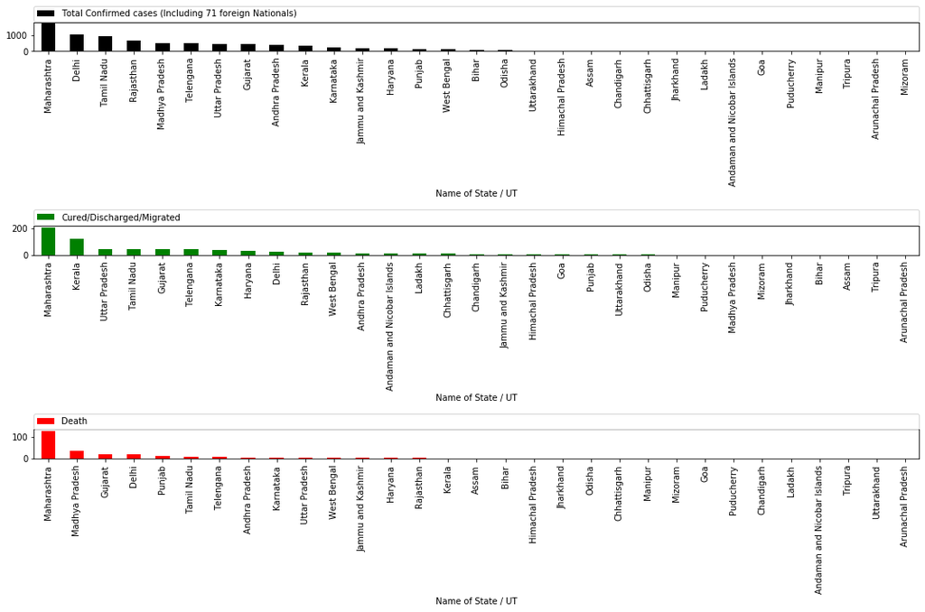

```python
fig, axs = plt.subplots(3,1,figsize=(15,10))
mohwf.sort_values([list(mohwf.columns)[1]], ascending=[False]).plot(x=list(mohwf.columns)[0], y=list(mohwf.columns)[1], kind = 'bar',color='k',ax=axs[0])
axs[0].legend(bbox_to_anchor=(0., 1.02, 1., .102), loc=3, ncol=4, mode="expand", borderaxespad=0.)
ax0=mohwf.sort_values([list(mohwf.columns)[2]], ascending=[False]).plot(x=list(mohwf.columns)[0], y=list(mohwf.columns)[2], kind = 'bar',color='g',ax=axs[1])
axs[1].legend(bbox_to_anchor=(0., 1.02, 1., .102), loc=3, ncol=4, mode="expand", borderaxespad=0.)
ax0=mohwf.sort_values([list(mohwf.columns)[3]], ascending=[False]).plot(x=list(mohwf.columns)[0], y=list(mohwf.columns)[3], kind = 'bar',color='r',ax=axs[2])
axs[2].legend(bbox_to_anchor=(0., 1.02, 1., .102), loc=3, ncol=4, mode="expand", borderaxespad=0.)
plt.tight_layout()
```

# [covid19india](https://www.covid19india.org) data analysis

```python
statewise,cases_time_series,tested=coviddata.statewise()
```

```python
statewise.iloc[0,:]
```

```
active                            7192
confirmed                         8453
deaths                             289
deltaconfirmed                       0
deltadeaths                          0
deltarecovered                       0
lastupdatedtime    12/04/2020 02:35:24
recovered                          972
state                            Total
statecode                           TT
Name: 0, dtype: object
```

```python
statewise.iloc[1:,:]
```

|  | active | confirmed | deaths | deltaconfirmed | deltadeaths | deltarecovered | lastupdatedtime | recovered | state | statecode |
| --- | --- | --- | --- | --- | --- | --- | --- | --- | --- | --- |
| 1 | 1426 | 1761 | 127 | 0 | 0 | 0 | 11/04/2020 22:35:24 | 208 | Maharashtra | MH |
| 2 | 915 | 969 | 10 | 0 | 0 | 0 | 11/04/2020 18:55:24 | 44 | Tamil Nadu | TN |
| 3 | 1023 | 1069 | 19 | 0 | 0 | 0 | 11/04/2020 21:13:10 | 27 | Delhi | DL |
| 4 | 393 | 503 | 14 | 0 | 0 | 0 | 11/04/2020 22:10:24 | 96 | Telangana | TG |
| 5 | 575 | 700 | 9 | 0 | 0 | 0 | 12/04/2020 02:35:25 | 116 | Rajasthan | RJ |
| 6 | 228 | 373 | 2 | 0 | 0 | 0 | 11/04/2020 18:20:24 | 143 | Kerala | KL |
| 7 | 402 | 452 | 5 | 0 | 0 | 0 | 11/04/2020 19:50:25 | 45 | Uttar Pradesh | UP |
| 8 | 389 | 405 | 6 | 0 | 0 | 0 | 11/04/2020 18:55:25 | 10 | Andhra Pradesh | AP |
| 9 | 451 | 529 | 40 | 0 | 0 | 0 | 11/04/2020 23:35:25 | 38 | Madhya Pradesh | MP |
| 10 | 170 | 215 | 6 | 0 | 0 | 0 | 11/04/2020 19:20:25 | 39 | Karnataka | KA |
| 11 | 402 | 468 | 22 | 0 | 0 | 0 | 11/04/2020 20:20:24 | 44 | Gujarat | GJ |
| 12 | 141 | 179 | 2 | 0 | 0 | 0 | 11/04/2020 19:05:26 | 36 | Haryana | HR |
| 13 | 214 | 224 | 4 | 0 | 0 | 0 | 09/04/2020 19:35:27 | 6 | Jammu and Kashmir | JK |
| 14 | 126 | 158 | 12 | 0 | 0 | 0 | 11/04/2020 18:55:26 | 20 | Punjab | PB |
| 15 | 105 | 126 | 5 | 0 | 0 | 0 | 11/04/2020 19:20:26 | 16 | West Bengal | WB |
| 16 | 41 | 54 | 1 | 0 | 0 | 0 | 11/04/2020 23:35:26 | 12 | Odisha | OR |
| 17 | 48 | 64 | 1 | 0 | 0 | 0 | 11/04/2020 23:35:28 | 15 | Bihar | BR |
| 18 | 30 | 35 | 0 | 0 | 0 | 0 | 08/04/2020 21:20:26 | 5 | Uttarakhand | UT |
| 19 | 28 | 29 | 1 | 0 | 0 | 0 | 10/04/2020 10:20:25 | 0 | Assam | AS |
| 20 | 12 | 19 | 0 | 0 | 0 | 0 | 10/04/2020 18:10:27 | 7 | Chandigarh | CH |
| 21 | 22 | 32 | 2 | 0 | 0 | 0 | 11/04/2020 22:00:34 | 8 | Himachal Pradesh | HP |
| 22 | 4 | 15 | 0 | 0 | 0 | 0 | 10/04/2020 11:20:26 | 11 | Ladakh | LA |
| 23 | 1 | 11 | 0 | 0 | 0 | 0 | 30/03/2020 11:27:27 | 10 | Andaman and Nicobar Islands | AN |
| 24 | 16 | 25 | 0 | 0 | 0 | 0 | 12/04/2020 01:10:26 | 9 | Chhattisgarh | CT |
| 25 | 2 | 7 | 0 | 0 | 0 | 0 | 11/04/2020 23:26:44 | 5 | Goa | GA |
| 26 | 6 | 7 | 0 | 0 | 0 | 0 | 10/04/2020 17:50:26 | 1 | Puducherry | PY |
| 27 | 16 | 17 | 1 | 0 | 0 | 0 | 11/04/2020 11:55:30 | 0 | Jharkhand | JH |
| 28 | 1 | 2 | 0 | 0 | 0 | 0 | 06/04/2020 22:35:54 | 1 | Manipur | MN |
| 29 | 1 | 1 | 0 | 0 | 0 | 0 | 26/03/2020 07:19:29 | 0 | Mizoram | MZ |
| 30 | 1 | 1 | 0 | 0 | 0 | 0 | 02/04/2020 11:42:31 | 0 | Arunachal Pradesh | AR |
| 31 | 1 | 1 | 0 | 0 | 0 | 0 | 06/04/2020 15:22:25 | 0 | Dadra and Nagar Haveli | DN |
| 32 | 2 | 2 | 0 | 0 | 0 | 0 | 10/04/2020 20:00:27 | 0 | Tripura | TR |
| 33 | 0 | 0 | 0 | 0 | 0 | 0 | 26/03/2020 07:19:29 | 0 | Daman and Diu | DD |
| 34 | 0 | 0 | 0 | 0 | 0 | 0 | 26/03/2020 07:19:29 | 0 | Lakshadweep | LD |
| 35 | 0 | 0 | 0 | 0 | 0 | 0 | 26/03/2020 07:19:29 | 0 | Meghalaya | ML |
| 36 | 0 | 0 | 0 | 0 | 0 | 0 | 26/03/2020 07:19:29 | 0 | Nagaland | NL |
| 37 | 0 | 0 | 0 | 0 | 0 | 0 | 26/03/2020 07:19:29 | 0 | Sikkim | SK |

```python
statewise[["active","confirmed","deaths","recovered"]]=statewise[["active","confirmed","deaths","recovered"]].astype(int)
```

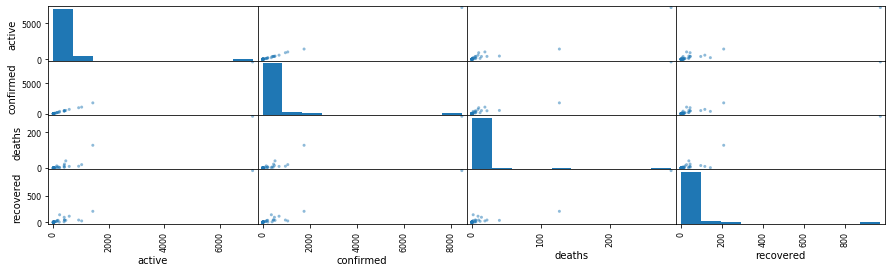

```python
from pandas.plotting import scatter_matrix
scatter_matrix(statewise)
plt.show()
```

```python
corr = statewise.corr(method ='spearman')
corr.style.background_gradient(cmap='coolwarm')
```

|  | active | confirmed | deaths | recovered |
| --- | --- | --- | --- | --- |
| active | 1.000000 | 0.994124 | 0.920328 | 0.877619 |
| confirmed | 0.994124 | 1.000000 | 0.918665 | 0.902151 |
| deaths | 0.920328 | 0.918665 | 1.000000 | 0.813363 |
| recovered | 0.877619 | 0.902151 | 0.813363 | 1.000000 |

This shows recovery rate is very low in case of India as active and confirmed cases are highly coorelated.

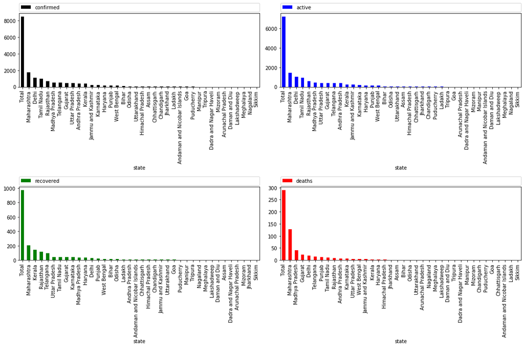

```python
fig, axs = plt.subplots(2,2,figsize=(15,10))
statewise.sort_values(['confirmed'], ascending=[False]).plot(x='state', y='confirmed', kind = 'bar',color='k',ax=axs[0,0])
axs[0,0].legend(bbox_to_anchor=(0., 1.02, 1., .102), loc=3, ncol=4, mode="expand", borderaxespad=0.)
statewise.sort_values(['active'], ascending=[False]).plot(x='state', y='active', kind = 'bar',color='b',ax=axs[0,1])
axs[0,1].legend(bbox_to_anchor=(0., 1.02, 1., .102), loc=3, ncol=4, mode="expand", borderaxespad=0.)
ax0=statewise.sort_values(['recovered'], ascending=[False]).plot(x='state', y='recovered', kind = 'bar',color='g',ax=axs[1,0])
axs[1,0].legend(bbox_to_anchor=(0., 1.02, 1., .102), loc=3, ncol=4, mode="expand", borderaxespad=0.)
ax0=statewise.sort_values(['deaths'], ascending=[False]).plot(x='state', y='deaths', kind = 'bar',color='r',ax=axs[1,1])
axs[1,1].legend(bbox_to_anchor=(0., 1.02, 1., .102), loc=3, ncol=4, mode="expand", borderaxespad=0.)
plt.tight_layout()
```

```python
cases_time_series[["dailyconfirmed","dailydeceased","dailyrecovered","totalconfirmed","totaldeceased","totalrecovered"]]=cases_time_series[["dailyconfirmed","dailydeceased","dailyrecovered","totalconfirmed","totaldeceased","totalrecovered"]].astype(int)
cases_time_series
```

|  | dailyconfirmed | dailydeceased | dailyrecovered | date | totalconfirmed | totaldeceased | totalrecovered |
| --- | --- | --- | --- | --- | --- | --- | --- |
| 0 | 1 | 0 | 0 | 30 January | 1 | 0 | 0 |
| 1 | 0 | 0 | 0 | 31 January | 1 | 0 | 0 |
| 2 | 0 | 0 | 0 | 01 February | 1 | 0 | 0 |
| 3 | 1 | 0 | 0 | 02 February | 2 | 0 | 0 |
| 4 | 1 | 0 | 0 | 03 February | 3 | 0 | 0 |
| ... | ... | ... | ... | ... | ... | ... | ... |
| 69 | 565 | 20 | 96 | 08 April | 5916 | 184 | 565 |
| 70 | 813 | 46 | 70 | 09 April | 6729 | 230 | 635 |
| 71 | 871 | 22 | 151 | 10 April | 7600 | 252 | 786 |
| 72 | 854 | 40 | 186 | 11 April | 8454 | 292 | 972 |
| 73 | 0 | 0 | 0 | 12 April | 8454 | 292 | 972 |

74 rows × 7 columns

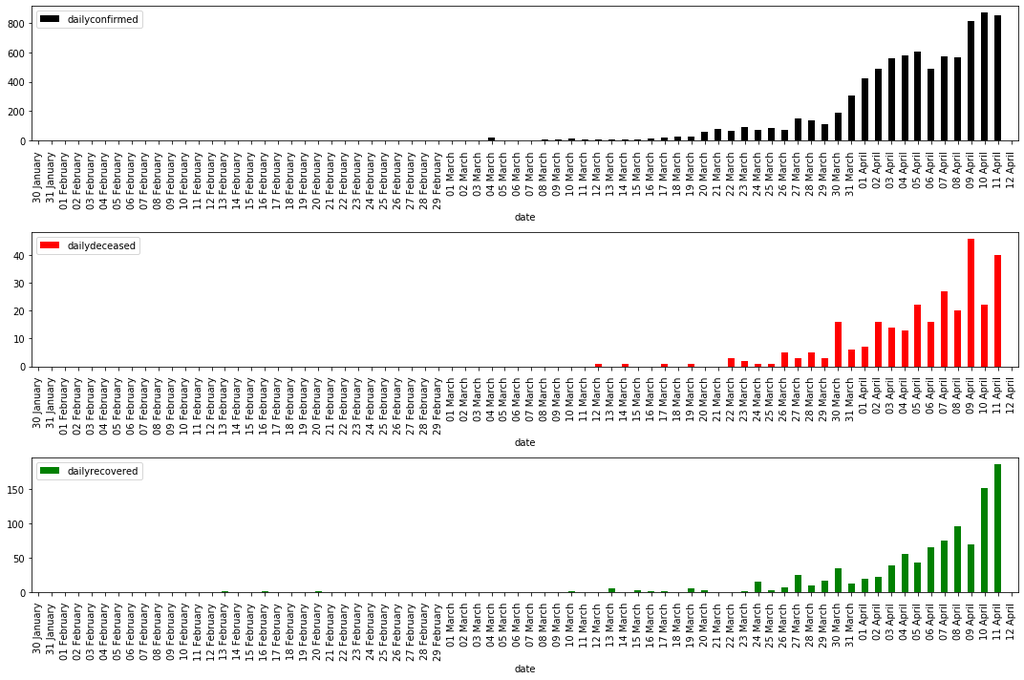

```python
fig, axs = plt.subplots(3,1,figsize=(15,10))
cases_time_series.plot(x='date', y='dailyconfirmed',kind = 'bar',color='k',ax=axs[0])
cases_time_series.plot(x='date', y='dailydeceased',kind = 'bar',color='r',ax=axs[1])
cases_time_series.plot(x='date', y='dailyrecovered',kind = 'bar',color='g',ax=axs[2])
plt.tight_layout()
```

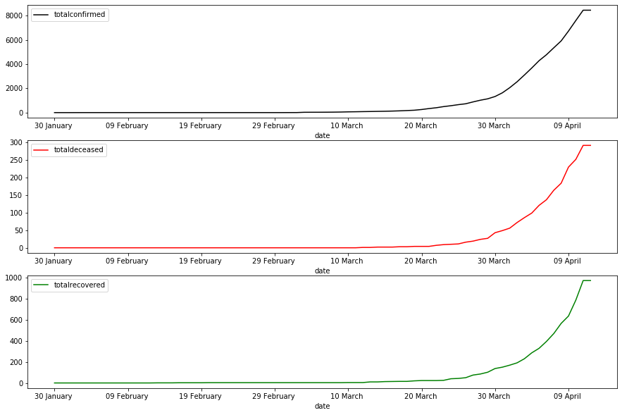

```python
fig, axs = plt.subplots(3,1,figsize=(15,10))
cases_time_series.plot(x='date', y='totalconfirmed',color='k',ax=axs[0])
cases_time_series.plot(x='date', y='totaldeceased',color='r',ax=axs[1])
cases_time_series.plot(x='date', y='totalrecovered',color='g',ax=axs[2])
```

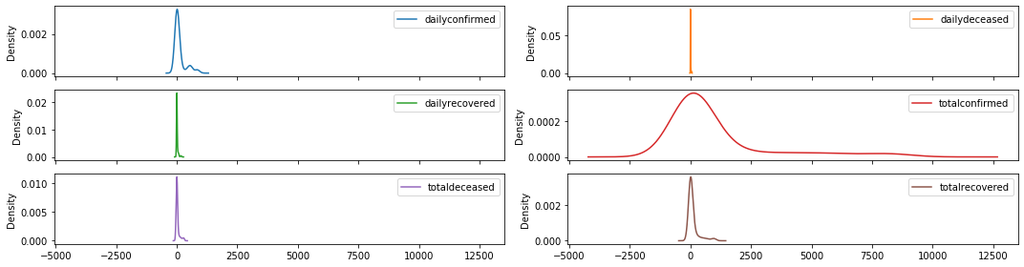

```python
cases_time_series[["dailyconfirmed","dailydeceased","dailyrecovered","totalconfirmed","totaldeceased","totalrecovered"]].plot(kind='density', subplots=True, layout=(3,2), sharex=True)
plt.tight_layout()
```

```python
corr = cases_time_series[["dailyconfirmed","dailydeceased","dailyrecovered"]].corr(method ='spearman')
corr.style.background_gradient(cmap='coolwarm')
```

|  | dailyconfirmed | dailydeceased | dailyrecovered |
| --- | --- | --- | --- |
| dailyconfirmed | 1.000000 | 0.846977 | 0.804506 |
| dailydeceased | 0.846977 | 1.000000 | 0.830211 |
| dailyrecovered | 0.804506 | 0.830211 | 1.000000 |

A **Pearson correlation** is a measure of a linear association between 2 normally distributed random variables. A **Spearman rank correlation** describes the monotonic relationship between 2 variables.

```python
tested
```

|  | positivecasesfromsamplesreported | samplereportedtoday | source | testsconductedbyprivatelabs | totalindividualstested | totalpositivecases | totalsamplestested | updatetimestamp |
| --- | --- | --- | --- | --- | --- | --- | --- | --- |
| 0 |  |  | Press_Release_ICMR_13March2020.pdf |  | 5900 | 78 | 6500 | 13/03/2020 12:00: am |
| 1 |  |  | ICMR_website_update_18March_6PM_IST.pdf |  | 12235 | 150 | 13125 | 18/03/2020 06:00: pm |
| 2 |  |  | ICMR_website_update_19March_10AM_IST_V2.pdf |  | 12426 | 168 | 13316 | 19/03/2020 10:00: am |
| 3 |  |  | ICMR_website_update_19March_6PM_IST.pdf |  | 13285 | 182 | 14175 | 19/03/2020 06:00: pm |
| 4 |  |  | ICMR_website_update_20March_10AM_IST.pdf |  | 13486 | 206 | 14376 | 20/03/2020 10:00: am |
| 5 |  |  | ICMR_website_update_20March_6PM_IST.pdf |  | 14514 | 236 | 15404 | 20/03/2020 06:00: pm |
| 6 |  |  | ICMR_website_update_21March_10AM_IST.pdf |  | 14811 | 271 | 15701 | 21/03/2020 10:00: am |
| 7 |  |  | ICMR_website_update_21March_6PM_IST.pdf |  | 16021 | 315 | 16911 | 21/03/2020 06:00: pm |
| 8 |  |  | ICMR_website_update_22March_10AM_IST.pdf |  | 16109 | 341 | 16999 | 22/03/2020 10:00: am |
| 9 |  |  | ICMR_website_update_22March_6PM_IST.pdf |  | 17237 | 396 | 18127 | 22/03/2020 06:00: pm |
| 10 |  |  | ICMR_website_update_23March_10AM_IST.pdf |  | 17493 | 415 | 18383 | 23/03/2020 10:00: am |
| 11 |  |  | ICMR_website_update_23March_8PM_IST.pdf |  | 19817 | 471 | 20707 | 23/03/2020 08:00: pm |
| 12 |  |  | ICMR_website_update_24March_10AM_IST.pdf |  | 19974 | 482 | 20864 | 24/03/2020 10:00: am |
| 13 |  |  | ICMR_website_update_24March_8PM_IST.pdf |  | 21804 | 536 | 22694 | 24/03/2020 08:00: pm |
| 14 |  |  | ICMR_website_update_25March_10AM_IST.pdf |  | 22038 | 539 | 22928 | 25/03/2020 10:00: am |
| 15 |  |  | ICMR_website_update_25March_8PM_IST.pdf |  | 24254 | 581 | 25144 | 25/03/2020 08:00: pm |
| 16 |  |  |  |  |  |  |  | 26/03/2020 10:00: am |
| 17 |  |  |  |  |  |  |  | 26/03/2020 06:00: pm |
| 18 |  |  | ICMR_website_update_27March_9AM_IST.pdf |  | 26798 | 691 | 27688 | 27/03/2020 09:00: am |
| 19 |  |  | MoH Press conference with Dr. Raman G | 1334 |  |  | 38442 | 30/03/2020 12:00: am |
| 20 |  |  | MoH Press conference with Dr. Raman G | 1733 |  |  | 42788 | 31/03/2020 12:00: am |
| 21 |  |  | https://twitter.com/PTI_News/status/1245308976... | 4562 |  | 1637 | 47951 | 01/04/2020 12:00: am |
| 22 |  |  | ICMR_testing_update_02April_9PM_IST.pdf |  |  | 2056 | 55851 | 02/04/2020 09:00: pm |
| 23 |  |  | ICMR_testing_update_03April_9AM_IST.pdf |  |  | 2183 | 56680 | 03/04/2020 09:00: am |
| 24 | 575 | 10034 | ICMR_testing_update_03April_9PM_IST.pdf |  |  | 2653 | 69245 | 03/04/2020 09:00: pm |
| 25 |  |  | https://icmr.nic.in/sites/default/files/whats_... |  |  | 3113 | 79950 | 04/04/2020 09:00: pm |
| 26 | 295 | 9369 | https://icmr.nic.in/sites/default/files/whats_... |  |  | 3554 | 89534 | 05/04/2020 09:00: pm |
| 27 | 311 | 11432 | https://icmr.nic.in/sites/default/files/whats_... |  |  | 4135 | 101068 | 06/04/2020 09:00: pm |
| 28 | 285 | 12584 | ICMR_testing_update_07April_9PM_IST.pdf |  |  | 4616 | 114015 | 07/04/2020 09:00: pm |
| 29 | 320 | 13143 | https://icmr.nic.in/sites/default/files/whats_... |  |  | 5114 | 127919 | 08/04/2020 09:00: pm |
| 30 | 320 | 16002 | https://icmr.nic.in/sites/default/files/whats_... |  | 130792 | 5705 | 144910 | 09/04/2020 09:00: pm |
| 31 | 433 | 15663 | https://icmr.nic.in/sites/default/files/whats_... |  | 147034 | 6872 | 161330 | 10/04/2020 09:00: pm |
| 32 | 600 | 17143 | https://icmr.nic.in/sites/default/files/whats_... |  | 164773 | 7703 | 179374 | 11/04/2020 09:00: pm |

```python
tested['totalindividualstested'].replace('', 0, inplace=True)
tested['totalpositivecases'].replace('', 0, inplace=True)
tested['totalsamplestested'].replace('', 0, inplace=True)
tested['testsconductedbyprivatelabs'].replace('', 0, inplace=True)
tested['positivecasesfromsamplesreported'].replace('', 0, inplace=True)
tested['samplereportedtoday'].replace('', 0, inplace=True)
```

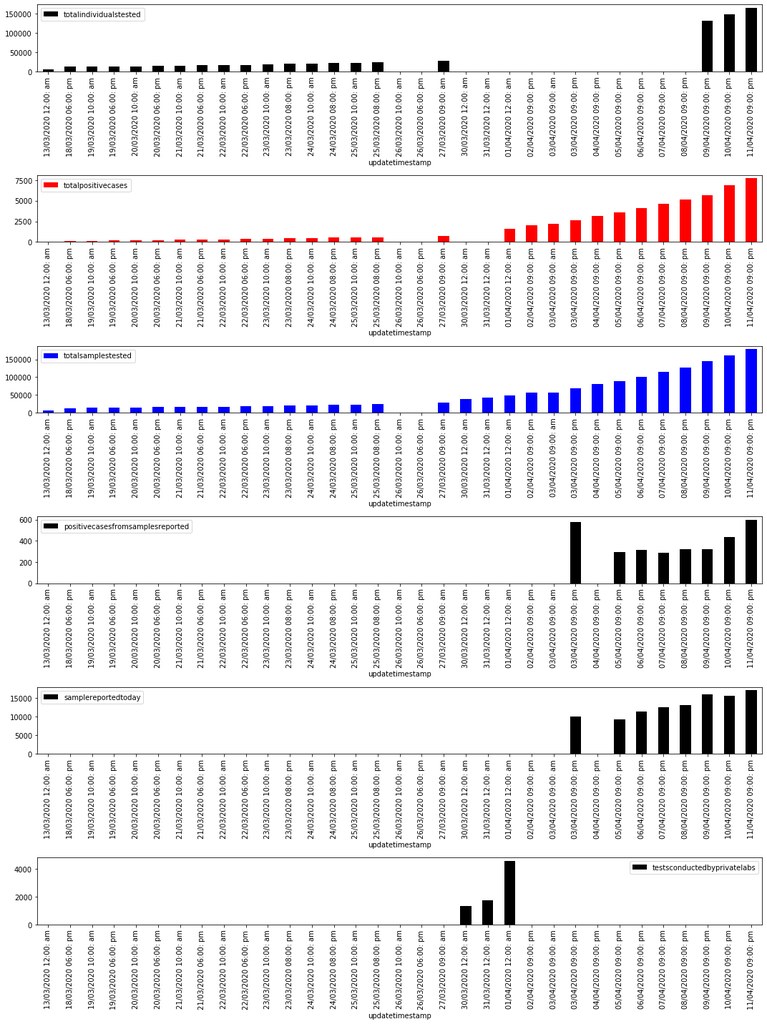

```python
import pandas as pd
# tested["updatetimestamp"]=tested["updatetimestamp"].apply(pd.to_datetime)
tested[['positivecasesfromsamplesreported','samplereportedtoday','testsconductedbyprivatelabs','totalindividualstested','totalpositivecases','totalsamplestested']]=tested[['positivecasesfromsamplesreported','samplereportedtoday','testsconductedbyprivatelabs','totalindividualstested','totalpositivecases','totalsamplestested']].astype(int)
fig, axs = plt.subplots(6,1,figsize=(15,20))
tested.plot(kind='bar',x='updatetimestamp', y='totalindividualstested',color='k',ax=axs[0])
tested.plot(kind='bar',x='updatetimestamp', y='totalpositivecases',color='r',ax=axs[1])
tested.plot(kind='bar',x='updatetimestamp', y='totalsamplestested',color='b',ax=axs[2])
tested.plot(kind='bar',x='updatetimestamp', y='positivecasesfromsamplesreported',color='k',ax=axs[3])
tested.plot(kind='bar',x='updatetimestamp', y='samplereportedtoday',color='k',ax=axs[4])
tested.plot(kind='bar',x='updatetimestamp', y='testsconductedbyprivatelabs',color='k',ax=axs[5])
plt.tight_layout()
```

```python
data=coviddata.raw_data_info()
data
```

|  | agebracket | backupnotes | contractedfromwhichpatientsuspected | currentstatus | dateannounced | detectedcity | detecteddistrict | detectedstate | estimatedonsetdate | gender | nationality | notes | patientnumber | source1 | source2 | source3 | statecode | statepatientnumber | statuschangedate | typeoftransmission |
| --- | --- | --- | --- | --- | --- | --- | --- | --- | --- | --- | --- | --- | --- | --- | --- | --- | --- | --- | --- | --- |
| 0 | 20 | Student from Wuhan |  | Recovered | 30/01/2020 | Thrissur | Thrissur | Kerala |  | F | India | Travelled from Wuhan | 1 | https://twitter.com/vijayanpinarayi/status/122... | https://weather.com/en-IN/india/news/news/2020... |  | KL | KL-TS-P1 | 14/02/2020 | Imported |
| 1 |  | Student from Wuhan |  | Recovered | 02/02/2020 | Alappuzha | Alappuzha | Kerala |  |  | India | Travelled from Wuhan | 2 | https://www.indiatoday.in/india/story/kerala-r... | https://weather.com/en-IN/india/news/news/2020... |  | KL | KL-AL-P1 | 14/02/2020 | Imported |
| 2 |  | Student from Wuhan |  | Recovered | 03/02/2020 | Kasaragod | Kasaragod | Kerala |  |  | India | Travelled from Wuhan | 3 | https://www.indiatoday.in/india/story/kerala-n... | https://twitter.com/ANI/status/122422148580539... | https://weather.com/en-IN/india/news/news/2020... | KL | KL-KS-P1 | 14/02/2020 | Imported |
| 3 | 45 | Travel history to Italy and Austria |  | Recovered | 02/03/2020 | East Delhi (Mayur Vihar) | East Delhi | Delhi |  | M | India | Travelled from Austria, Italy | 4 | https://www.indiatoday.in/india/story/not-a-ja... | https://economictimes.indiatimes.com/news/poli... |  | DL | DL-P1 | 15/03/2020 | Imported |
| 4 | 24 | Travel history to Dubai, Singapore contact |  | Recovered | 02/03/2020 | Hyderabad | Hyderabad | Telangana |  | M | India | Travelled from Dubai to Bangalore on 20th Feb,... | 5 | https://www.deccanherald.com/national/south/qu... | https://www.indiatoday.in/india/story/coronavi... | https://www.thehindu.com/news/national/coronav... | TG | TS-P1 | 02/03/2020 | Imported |
| ... | ... | ... | ... | ... | ... | ... | ... | ... | ... | ... | ... | ... | ... | ... | ... | ... | ... | ... | ... | ... |
| 8604 |  |  |  |  |  |  |  |  |  |  |  |  | 8605 |  |  |  |  |  |  |  |
| 8605 |  |  |  |  |  |  |  |  |  |  |  |  | 8606 |  |  |  |  |  |  |  |
| 8606 |  |  |  |  |  |  |  |  |  |  |  |  | 8607 |  |  |  |  |  |  |  |
| 8607 |  |  |  |  |  |  |  |  |  |  |  |  | 8608 |  |  |  |  |  |  |  |
| 8608 |  |  |  |  |  |  |  |  |  |  |  |  | 8609 |  |  |  |  |  |  |  |

8609 rows × 20 columns

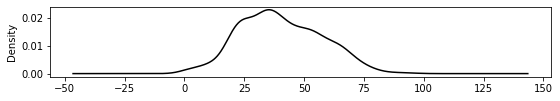

```python
data.query('agebracket != "" & agebracket != "28-35"').agebracket.astype(int).plot(kind='density', subplots=True, layout=(3,2), sharex=True,color="k")
plt.tight_layout()
```

```python
data.query('agebracket != "" & agebracket != "28-35"').agebracket.astype(int).describe()
```

```
count    1176.000000
mean       40.421769
std        16.921315
min         1.000000
25%        27.000000
50%        39.000000
75%        53.000000
max        96.000000
Name: agebracket, dtype: float64
```

```python
data1=data.query('agebracket != "" & agebracket != "28-35"')
data1.agebracket=data1.agebracket.astype(int)
print("Statistics for age group 27-53")
data1.query('agebracket >=25 and agebracket <=53').currentstatus.value_counts()
```

[output not shown]

```
Hospitalized    626
Recovered        40
Deceased          5
Name: currentstatus, dtype: int64
```

```python
print("Statistics for age less than 27")
data1.query('agebracket <25').currentstatus.value_counts()
```

[output not shown]

```
Hospitalized    202
Recovered        20
Deceased          1
Name: currentstatus, dtype: int64
```

```python
print("Statistics for age more than 53")
data1.query('agebracket >=53').currentstatus.value_counts()
```

```
Statistics for age more than 53
```

```
Hospitalized    240
Recovered        34
Deceased         23
Name: currentstatus, dtype: int64
```

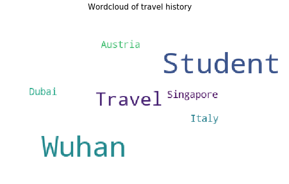

```python
from wordcloud import WordCloud, STOPWORDS
import matplotlib.pyplot as plt
stopwords =list(STOPWORDS)
stopwords.extend(["_d180g","Object","Name","NaN","dtype","Length","backupnotes","contact","history"])
def show_wordcloud(data, title = None):
    wordcloud = WordCloud(background_color='white',stopwords=stopwords,max_words=200,max_font_size=40, relative_scaling = 1,random_state=1).generate(str(data))
    fig = plt.figure(1, figsize=(10,10))
    plt.axis('off')
    if title:
        fig.suptitle(title, fontsize=15)
        fig.subplots_adjust(top=1.25)

    plt.imshow(wordcloud)
    plt.show()
show_wordcloud(data['backupnotes'],title = "Wordcloud of travel history")
```

```python
data
```

|  | agebracket | backupnotes | contractedfromwhichpatientsuspected | currentstatus | dateannounced | detectedcity | detecteddistrict | detectedstate | estimatedonsetdate | gender | nationality | notes | patientnumber | source1 | source2 | source3 | statecode | statepatientnumber | statuschangedate | typeoftransmission |
| --- | --- | --- | --- | --- | --- | --- | --- | --- | --- | --- | --- | --- | --- | --- | --- | --- | --- | --- | --- | --- |
| 0 | 20 | Student from Wuhan |  | Recovered | 30/01/2020 | Thrissur | Thrissur | Kerala |  | F | India | Travelled from Wuhan | 1 | https://twitter.com/vijayanpinarayi/status/122... | https://weather.com/en-IN/india/news/news/2020... |  | KL | KL-TS-P1 | 14/02/2020 | Imported |
| 1 |  | Student from Wuhan |  | Recovered | 02/02/2020 | Alappuzha | Alappuzha | Kerala |  |  | India | Travelled from Wuhan | 2 | https://www.indiatoday.in/india/story/kerala-r... | https://weather.com/en-IN/india/news/news/2020... |  | KL | KL-AL-P1 | 14/02/2020 | Imported |
| 2 |  | Student from Wuhan |  | Recovered | 03/02/2020 | Kasaragod | Kasaragod | Kerala |  |  | India | Travelled from Wuhan | 3 | https://www.indiatoday.in/india/story/kerala-n... | https://twitter.com/ANI/status/122422148580539... | https://weather.com/en-IN/india/news/news/2020... | KL | KL-KS-P1 | 14/02/2020 | Imported |
| 3 | 45 | Travel history to Italy and Austria |  | Recovered | 02/03/2020 | East Delhi (Mayur Vihar) | East Delhi | Delhi |  | M | India | Travelled from Austria, Italy | 4 | https://www.indiatoday.in/india/story/not-a-ja... | https://economictimes.indiatimes.com/news/poli... |  | DL | DL-P1 | 15/03/2020 | Imported |
| 4 | 24 | Travel history to Dubai, Singapore contact |  | Recovered | 02/03/2020 | Hyderabad | Hyderabad | Telangana |  | M | India | Travelled from Dubai to Bangalore on 20th Feb,... | 5 | https://www.deccanherald.com/national/south/qu... | https://www.indiatoday.in/india/story/coronavi... | https://www.thehindu.com/news/national/coronav... | TG | TS-P1 | 02/03/2020 | Imported |
| ... | ... | ... | ... | ... | ... | ... | ... | ... | ... | ... | ... | ... | ... | ... | ... | ... | ... | ... | ... | ... |
| 8604 |  |  |  |  |  |  |  |  |  |  |  |  | 8605 |  |  |  |  |  |  |  |
| 8605 |  |  |  |  |  |  |  |  |  |  |  |  | 8606 |  |  |  |  |  |  |  |
| 8606 |  |  |  |  |  |  |  |  |  |  |  |  | 8607 |  |  |  |  |  |  |  |
| 8607 |  |  |  |  |  |  |  |  |  |  |  |  | 8608 |  |  |  |  |  |  |  |
| 8608 |  |  |  |  |  |  |  |  |  |  |  |  | 8609 |  |  |  |  |  |  |  |

8609 rows × 20 columns

```python
# from TM import Topic_modeling
# tm=Topic_modeling(data,"notes")# Put your DataFrame as first argument and columns name whose topic modelling you want to do as second argument
# tm.modeling()
```

Text mining results of object dtypes columns

- [notes](https://ashishcssom.github.io/Covid19-data-analysis-on-Indian-dataset/notes.html)
- [backupnotes](https://ashishcssom.github.io/Covid19-data-analysis-on-Indian-dataset/backupnotes.html)

```
count     1957
unique       2
top          M
freq      1415
Name: gender, dtype: object
```

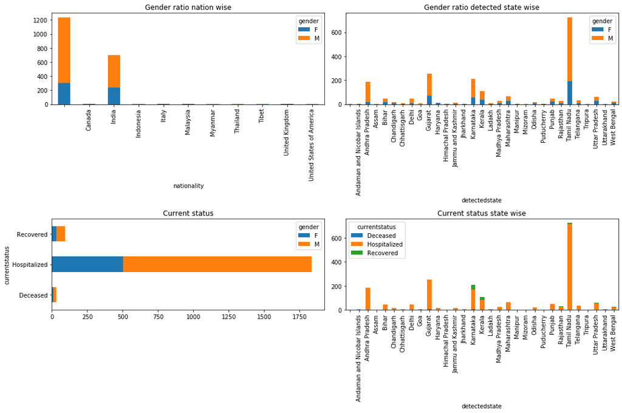

```python
data2=data.query('gender != ""')
fig, axs = plt.subplots(2,2,figsize=(15,10))
data2.groupby(['nationality',"gender"]).size().unstack().plot(kind='bar', stacked=True,title="Gender ratio nation wise",ax=axs[0,0])
data2.groupby(['detectedstate',"gender"]).size().unstack().plot(kind='bar', stacked=True,title="Gender ratio detected state wise",ax=axs[0,1])
data2.groupby(['currentstatus',"gender"]).size().unstack().plot(kind='barh', stacked=True,title="Current status",ax=axs[1,0])
data2.groupby(['detectedstate','currentstatus']).size().unstack().plot(kind='bar', stacked=True,title="Current status state wise",ax=axs[1,1])
plt.tight_layout()
data2.gender.describe()
```

Males are more infected to this virus. Reason could be `less immunity`, `more travel` or `respiratory illness` due to `smoking habit`

```python
coviddata.travel_history()
```

|  | _cn6ca | accuracylocation | address | datasource | latlong | modeoftravel | pid | placename | timefrom | timeto | type | _d2mkx |
| --- | --- | --- | --- | --- | --- | --- | --- | --- | --- | --- | --- | --- |
| 0 | 1 |  | Hotel Aryas, Kuthattukulam, Muvattupuzha road | https://drive.google.com/drive/folders/1yAgt3I... | 9.8614231,76.5900643 |  | P35 |  | 29/02/2020 10:30:00 | 29/02/2020 11:30:00 | placeVisit | NaN |
| 1 | 2 |  | Suresh Hotel Ranni | https://drive.google.com/drive/folders/1yAgt3I... | 9.3823686,76.779199 |  | P35 |  | 01/03/2020 21:30:00 | 01/03/2020 23:00:00 | placeVisit | NaN |
| 2 | 3 |  | Post Office Ranni Pazvangadi, Ranni | https://drive.google.com/drive/folders/1yAgt3I... | 9.3757533,76.7763825 |  | P35 |  | 02/03/2020 11:00:00 | 02/03/2020 11:30:00 | placeVisit | NaN |
| 3 | 4 |  | Knanaya Church, Pazvangadi Ranni | https://drive.google.com/drive/folders/1yAgt3I... | 9.375753,76.7698164 |  | P35 |  | 02/03/2020 11:30:00 | 02/03/2020 12:00:00 | placeVisit | NaN |
| 4 | 5 |  | Post Office Ranni Pazvangadi | https://drive.google.com/drive/folders/1yAgt3I... | 9.3757533,76.7763825 |  | P35 |  | 02/03/2020 12:00:00 | 02/03/2020 13:00:00 | placeVisit | NaN |
| ... | ... | ... | ... | ... | ... | ... | ... | ... | ... | ... | ... | ... |
| 234 | 235 |  | Walk in apartment with friend | https://drive.google.com/drive/folders/1yAgt3I... |  |  | P52 |  | 03/03/2020 17:30 | 03/03/2020 18:00 | placeVisit | NaN |
| 235 | 236 |  | Walk in apartment with friend | https://drive.google.com/drive/folders/1yAgt3I... |  |  | P52 |  | 03/07/2020 17:30 | 03/07/2020 18:00 | placeVisit | NaN |
| 236 | 237 |  | Bought medicine at Mediwave | https://drive.google.com/drive/folders/1yAgt3I... |  |  | P52 |  | 03/08/2020 14:30 | 03/08/2020 15:00 | placeVisit | NaN |
| 237 | 238 |  | Met Dhobi in apartment | https://drive.google.com/drive/folders/1yAgt3I... |  |  | P52 |  | 03/08/2020 20:30 | 03/08/2020 20:30 | placeVisit | NaN |
| 238 | 239 |  | Admitted in RJICD | https://drive.google.com/drive/folders/1yAgt3I... | 12.9383702, 77.5885142 |  | P52 | Health | 03/08/2020 20:30 | 03/08/2020 20:30 | placeVisit | NaN |

239 rows × 12 columns

```python
coviddata.state_district_data()
```

|  | State_UT | District | Confirmed |
| --- | --- | --- | --- |
| 0 | Kerala | Thrissur | 13 |
| 1 | Kerala | Alappuzha | 5 |
| 2 | Kerala | Kasaragod | 166 |
| 3 | Kerala | Pathanamthitta | 16 |
| 4 | Kerala | Kannur | 70 |
| ... | ... | ... | ... |
| 359 | Assam | Hailakandi | 1 |
| 360 | Arunachal Pradesh | Lohit | 1 |
| 361 | Dadra and Nagar Haveli | Unknown | 1 |
| 362 | Tripura | Gomati | 1 |
| 363 | Tripura | North Tripura | 1 |

364 rows × 3 columns

## Conclusion

In this analysis the data is retrive from two Ministry of Health and Family Welfare and covid19india website. After the analysis derived inferences are:

*Several more conclusions can be drawn from this analysis*